Skip to main content

# Data summary of my five flux towers

Author

Umme Salma

Published

July 12, 2027

# C1. Site overview

```python
import json
import zipfile
from pathlib import Path

import matplotlib.pyplot as plt
import numpy as np
import pandas as pd
from IPython.display import display


def find_project_root():
    for candidate in (Path.cwd(), *Path.cwd().parents):
        if (candidate / "data" / "raw").is_dir() and (
            candidate / "flux4student" / "sites.json"
        ).is_file():
            return candidate
    raise FileNotFoundError(
        "Could not locate the project root containing data/raw and flux4student/sites.json."
    )


project_root = find_project_root()
raw_dir = project_root / "data" / "raw"
zip_files = sorted(raw_dir.glob("*_FLUXNET_*.zip"))
if len(zip_files) != 5:
    raise ValueError(f"Expected five FLUXNET zip files in {raw_dir}; found {len(zip_files)}.")

keep = [
    "TIMESTAMP_START", "TIMESTAMP_END", "TA_F", "SW_IN_F", "VPD_F", "P_F",
    "NETRAD", "G_F_MDS", "H_F_MDS", "H_F_MDS_QC", "LE_F_MDS", "LE_F_MDS_QC",
    "NEE_VUT_REF", "NEE_VUT_REF_QC", "GPP_NT_VUT_REF", "RECO_NT_VUT_REF",
]


def read_hh(zip_file):
    zip_file = Path(zip_file)
    with zipfile.ZipFile(zip_file) as archive:
        members = [name for name in archive.namelist() if "FLUXMET_HH" in name]
        if not members:
            raise ValueError(f"No FLUXMET_HH file found in {zip_file.name}.")
        with archive.open(members[0]) as csv_file:
            hh = pd.read_csv(
                csv_file,
                na_values=[-9999],
                usecols=lambda column: column in keep,
                dtype={"TIMESTAMP_START": str, "TIMESTAMP_END": str},
            )

    hh["time"] = pd.to_datetime(hh["TIMESTAMP_START"], format="%Y%m%d%H%M")
    hh["site"] = zip_file.stem.split("_", maxsplit=2)[1]
    return hh


hh_all = pd.concat([read_hh(zip_file) for zip_file in zip_files], ignore_index=True)
sites = sorted(hh_all["site"].unique())
if len(sites) != 5:
    raise ValueError(f"Expected five distinct tower sites; found {sites}.")

registry = json.loads(
    (project_root / "flux4student" / "sites.json").read_text(encoding="utf-8")
)
registry_by_site = {row["id"]: row for row in registry}
missing_metadata = sorted(set(sites) - set(registry_by_site))
if missing_metadata:
    raise ValueError(f"Missing site metadata for: {', '.join(missing_metadata)}.")

country_names = {
    "AU": "Australia",
    "CN": "China",
    "CZ": "Czech Republic",
    "IT": "Italy",
    "US": "United States",
}
meta = pd.DataFrame(
    [
        {
            "SITE_ID": site,
            "SITE_NAME": registry_by_site[site]["name"],
            "COUNTRY": country_names.get(site[:2], site[:2]),
            "IGBP": registry_by_site[site]["igbp"],
            "LAT": registry_by_site[site]["lat"],
            "LON": registry_by_site[site]["lon"],
            "FIRST_YEAR": registry_by_site[site]["first"],
            "LAST_YEAR": registry_by_site[site]["last"],
            "HUB": registry_by_site[site]["hub"],
            "CITATION": registry_by_site[site]["cite"],
        }
        for site in sites
    ]
)

display(meta)
```

|  | SITE_ID | SITE_NAME | COUNTRY | IGBP | LAT | LON | FIRST_YEAR | LAST_YEAR | HUB | CITATION |
| --- | --- | --- | --- | --- | --- | --- | --- | --- | --- | --- |
| 0 | AU-Boy | Boyagin | Australia | EBF | -32.477093 | 116.938559 | 2017 | 2025 | TERN | Beringer, J., Moore, C. (2026): Boyagin FLUXNE... |
| 1 | CN-Jzh | Jinzhou | China | CRO | 41.148060 | 121.201670 | 2011 | 2016 | ICOS | Jia, Q., Zhou, G., Zhou, L. (2026). Fluxnet Ar... |
| 2 | CZ-BK1 | Bily Kriz forest | Czech Republic | ENF | 49.502075 | 18.536882 | 2004 | 2026 | ICOS | Šigut, L., Bellan, M., Czerný, R., Darenová, E... |
| 3 | IT-Cp2 | Castelporziano2 | Italy | MF | 41.704266 | 12.357293 | 2012 | 2026 | ICOS | Fares, S., Alivernini, A., Chianucci, F., Cont... |
| 4 | US-Seg | Sevilleta grassland | United States | GRA | 34.362300 | -106.702000 | 2007 | 2025 | AmeriFlux | Marcy Litvak (2026), AmeriFlux FLUXNET-1F US-S... |

The site information comes from the tracked `flux4student/sites.json` registry, so the report does not depend on a separate `data/site_snapshot.csv` file.

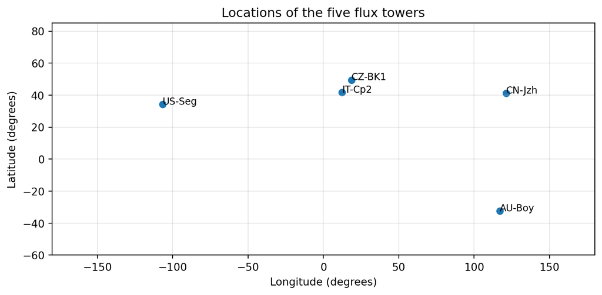

```python
fig, ax = plt.subplots(figsize=(8, 4))
ax.scatter(meta["LON"], meta["LAT"])

for _, row in meta.iterrows():
    ax.text(row["LON"], row["LAT"], row["SITE_ID"], fontsize=9)

ax.set_xlabel("Longitude (degrees)")
ax.set_ylabel("Latitude (degrees)")
ax.set_title("Locations of the five flux towers")
ax.set_xlim(-180, 180)
ax.set_ylim(-60, 85)
ax.grid(True, alpha=0.3)
fig.tight_layout()
plt.show()
```

# C2. Data coverage

Measured coverage is the share of half-hours where `NEE_VUT_REF_QC` equals zero.

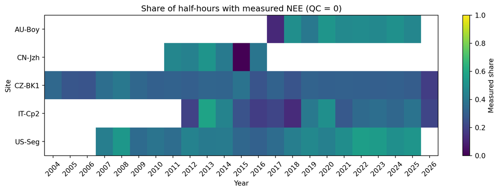

```
US-Seg has the highest average measured share across its years (43.5%); its three best years are 2022 (56.2%), 2023 (55.1%), 2008 (52.9%).
```

```python
hh_all["year"] = hh_all["time"].dt.year
coverage = (
    hh_all.assign(measured=hh_all["NEE_VUT_REF_QC"].eq(0))
    .groupby(["site", "year"])["measured"]
    .mean()
    .unstack("year")
    .reindex(sites)
)

fig, ax = plt.subplots(figsize=(11, 4))
image = ax.imshow(
    coverage.to_numpy(),
    aspect="auto",
    interpolation="nearest",
    vmin=0,
    vmax=1,
    cmap="viridis",
)
ax.set_yticks(np.arange(len(coverage.index)), labels=coverage.index)
ax.set_xticks(
    np.arange(len(coverage.columns)),
    labels=coverage.columns.astype(int),
    rotation=45,
)
ax.set_xlabel("Year")
ax.set_ylabel("Site")
ax.set_title("Share of half-hours with measured NEE (QC = 0)")
colorbar = fig.colorbar(image, ax=ax)
colorbar.set_label("Measured share")
fig.tight_layout()
plt.show()

mean_coverage = coverage.mean(axis=1).sort_values(ascending=False)
best_site = mean_coverage.index[0]
best_years = coverage.loc[best_site].dropna().sort_values(ascending=False).head(3)
year_summary = ", ".join(
    f"{int(year)} ({share:.1%})" for year, share in best_years.items()
)
print(
    f"{best_site} has the highest average measured share across its years "
    f"({mean_coverage.iloc[0]:.1%}); its three best years are {year_summary}."
)
```

# C3. Summary statistics

The statistics below use half-hourly values, except for `P_F`: precipitation is summed by calendar year, then its mean, minimum and maximum annual totals are reported. Missingness is the share of half-hours without a value. Units are included in each variable label.

```python
variable_units = {
    "TA_F": "deg C",
    "SW_IN_F": "W m-2",
    "VPD_F": "hPa",
    "P_F": "mm/year (annual sums)",
    "NEE_VUT_REF": "umol CO2 m-2 s-1",
    "GPP_NT_VUT_REF": "umol CO2 m-2 s-1",
    "RECO_NT_VUT_REF": "umol CO2 m-2 s-1",
    "H_F_MDS": "W m-2",
    "LE_F_MDS": "W m-2",
}

for variable, unit in variable_units.items():
    rows = []
    for site, group in hh_all.groupby("site", sort=True):
        values = group[variable]
        if variable == "P_F":
            annual_values = (
                pd.DataFrame({"year": group["time"].dt.year, "value": values})
                .groupby("year")["value"]
                .sum(min_count=1)
            )
            mean_value = annual_values.mean()
            min_value = annual_values.min()
            max_value = annual_values.max()
            statistic = f"annual total ({unit})"
        else:
            mean_value = values.mean()
            min_value = values.min()
            max_value = values.max()
            statistic = f"value ({unit})"

        rows.append(
            {
                "Site": site,
                f"Mean {statistic}": mean_value,
                f"Minimum {statistic}": min_value,
                f"Maximum {statistic}": max_value,
                "Missing (%)": values.isna().mean() * 100,
            }
        )

    print(variable)
    display(pd.DataFrame(rows).round(2))
```

```
TA_F
```

|  | Site | Mean value (deg C) | Minimum value (deg C) | Maximum value (deg C) | Missing (%) |
| --- | --- | --- | --- | --- | --- |
| 0 | AU-Boy | 16.27 | 2.05 | 42.38 | 0.00 |
| 1 | CN-Jzh | 8.97 | -24.81 | 36.69 | 0.00 |
| 2 | CZ-BK1 | 6.95 | -25.65 | 33.11 | 1.56 |
| 3 | IT-Cp2 | 16.99 | -5.16 | 37.95 | 2.39 |
| 4 | US-Seg | 13.99 | -20.15 | 38.58 | 0.00 |

```
SW_IN_F
```

|  | Site | Mean value (W m-2) | Minimum value (W m-2) | Maximum value (W m-2) | Missing (%) |
| --- | --- | --- | --- | --- | --- |
| 0 | AU-Boy | 231.02 | 0.0 | 1378.00 | 0.00 |
| 1 | CN-Jzh | 163.06 | 0.0 | 1012.00 | 0.00 |
| 2 | CZ-BK1 | 124.21 | 0.0 | 1127.81 | 1.56 |
| 3 | IT-Cp2 | 174.67 | 0.0 | 1014.00 | 2.39 |
| 4 | US-Seg | 232.20 | 0.0 | 1236.83 | 0.00 |

```
VPD_F
```

|  | Site | Mean value (hPa) | Minimum value (hPa) | Maximum value (hPa) | Missing (%) |
| --- | --- | --- | --- | --- | --- |
| 0 | AU-Boy | 9.08 | 0.01 | 72.93 | 0.00 |
| 1 | CN-Jzh | 6.30 | 0.32 | 47.27 | 0.00 |
| 2 | CZ-BK1 | 2.91 | 0.00 | 35.32 | 1.56 |
| 3 | IT-Cp2 | 5.02 | 0.00 | 52.69 | 2.39 |
| 4 | US-Seg | 12.93 | 0.00 | 64.35 | 0.00 |

```
P_F
```

|  | Site | Mean annual total (mm/year (annual sums)) | Minimum annual total (mm/year (annual sums)) | Maximum annual total (mm/year (annual sums)) | Missing (%) |
| --- | --- | --- | --- | --- | --- |
| 0 | AU-Boy | 511.69 | 324.10 | 685.43 | 0.00 |
| 1 | CN-Jzh | 541.24 | 409.36 | 681.00 | 0.00 |
| 2 | CZ-BK1 | 1198.19 | 576.36 | 1678.66 | 1.56 |
| 3 | IT-Cp2 | 758.59 | 439.98 | 1030.56 | 2.39 |
| 4 | US-Seg | 224.58 | 130.05 | 292.58 | 0.00 |

```
NEE_VUT_REF
```

|  | Site | Mean value (umol CO2 m-2 s-1) | Minimum value (umol CO2 m-2 s-1) | Maximum value (umol CO2 m-2 s-1) | Missing (%) |
| --- | --- | --- | --- | --- | --- |
| 0 | AU-Boy | -0.97 | -51.07 | 32.50 | 8.90 |
| 1 | CN-Jzh | -1.44 | -74.04 | 41.84 | 16.65 |
| 2 | CZ-BK1 | -1.83 | -61.98 | 49.89 | 1.63 |
| 3 | IT-Cp2 | -1.99 | -65.15 | 47.52 | 16.07 |
| 4 | US-Seg | -0.03 | -14.37 | 11.42 | 0.00 |

```
GPP_NT_VUT_REF
```

|  | Site | Mean value (umol CO2 m-2 s-1) | Minimum value (umol CO2 m-2 s-1) | Maximum value (umol CO2 m-2 s-1) | Missing (%) |
| --- | --- | --- | --- | --- | --- |
| 0 | AU-Boy | 3.10 | -31.45 | 51.25 | 8.90 |
| 1 | CN-Jzh | 3.71 | -41.24 | 84.72 | 16.65 |
| 2 | CZ-BK1 | 5.25 | -43.69 | 62.75 | 1.63 |
| 3 | IT-Cp2 | 6.00 | -37.69 | 70.34 | 19.90 |
| 4 | US-Seg | 0.43 | -9.52 | 16.93 | 0.00 |

```
RECO_NT_VUT_REF
```

|  | Site | Mean value (umol CO2 m-2 s-1) | Minimum value (umol CO2 m-2 s-1) | Maximum value (umol CO2 m-2 s-1) | Missing (%) |
| --- | --- | --- | --- | --- | --- |
| 0 | AU-Boy | 2.14 | 0.0 | 6.99 | 8.90 |
| 1 | CN-Jzh | 2.41 | 0.0 | 17.25 | 16.65 |
| 2 | CZ-BK1 | 3.49 | 0.0 | 43.75 | 1.63 |
| 3 | IT-Cp2 | 4.10 | 0.0 | 17.55 | 19.90 |
| 4 | US-Seg | 0.40 | 0.0 | 3.31 | 0.00 |

```
H_F_MDS
```

|  | Site | Mean value (W m-2) | Minimum value (W m-2) | Maximum value (W m-2) | Missing (%) |
| --- | --- | --- | --- | --- | --- |
| 0 | AU-Boy | 74.65 | -99.00 | 876.00 | 8.90 |
| 1 | CN-Jzh | 26.10 | -174.71 | 390.70 | 16.65 |
| 2 | CZ-BK1 | 31.17 | -299.87 | 942.69 | 1.36 |
| 3 | IT-Cp2 | 60.31 | -259.79 | 783.19 | 18.99 |
| 4 | US-Seg | 53.33 | -99.97 | 449.87 | 0.00 |

```
LE_F_MDS
```

|  | Site | Mean value (W m-2) | Minimum value (W m-2) | Maximum value (W m-2) | Missing (%) |
| --- | --- | --- | --- | --- | --- |
| 0 | AU-Boy | 29.25 | -76.00 | 544.00 | 8.90 |
| 1 | CN-Jzh | 37.78 | -210.25 | 767.10 | 16.65 |
| 2 | CZ-BK1 | 31.84 | -227.93 | 781.80 | 1.36 |
| 3 | IT-Cp2 | 39.81 | -199.23 | 854.35 | 15.58 |
| 4 | US-Seg | 17.28 | -20.00 | 447.62 | 0.00 |

# C4. Daily time series

Daily values are the arithmetic means of the half-hourly fluxes. The conversion is `1 umol CO2 m-2 s-1 = 1.0378 g C m-2 d-1`; negative NEE values are retained.

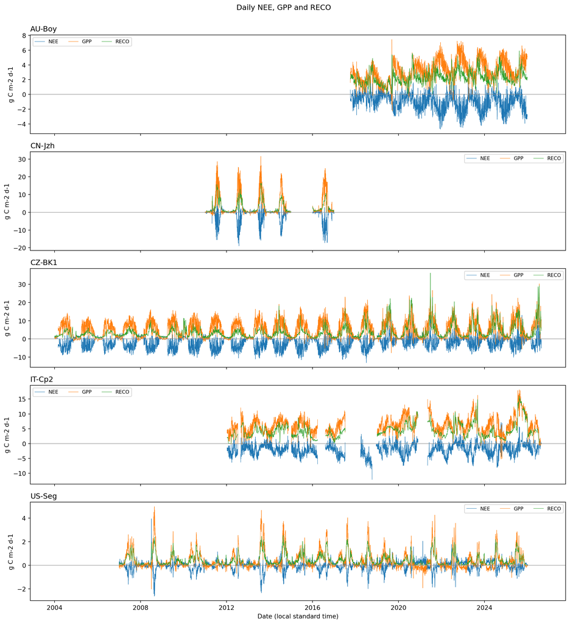

```python
carbon_fluxes = ["NEE_VUT_REF", "GPP_NT_VUT_REF", "RECO_NT_VUT_REF"]
daily = (
    hh_all.set_index("time")
    .groupby("site")[carbon_fluxes]
    .resample("D")
    .mean()
    .reset_index()
)
daily_gC = daily.copy()
daily_gC[carbon_fluxes] = daily_gC[carbon_fluxes] * 1.0378

fig, axes = plt.subplots(len(sites), 1, figsize=(13, 2.8 * len(sites)), sharex=True)
for ax, site in zip(axes, sites):
    site_daily = daily_gC.loc[daily_gC["site"] == site]
    for variable, label in [
        ("NEE_VUT_REF", "NEE"),
        ("GPP_NT_VUT_REF", "GPP"),
        ("RECO_NT_VUT_REF", "RECO"),
    ]:
        ax.plot(site_daily["time"], site_daily[variable], linewidth=0.55, label=label)
    ax.axhline(0, color="0.5", linewidth=0.6)
    ax.set_ylabel("g C m-2 d-1")
    ax.set_title(site, loc="left")
    ax.legend(ncol=3, fontsize=8)

axes[-1].set_xlabel("Date (local standard time)")
fig.suptitle("Daily NEE, GPP and RECO", y=1.002)
fig.tight_layout()
plt.show()
```

The half-hourly daily NEE mean is compared with the daily `FLUXMET_DD` NEE product for one site as an aggregation check.

```python
check_site = sites[0]
check_zip = next(
    path for path in zip_files
    if path.stem.split("_", maxsplit=2)[1] == check_site
)
with zipfile.ZipFile(check_zip) as archive:
    daily_members = [name for name in archive.namelist() if "FLUXMET_DD" in name]
    if not daily_members:
        raise ValueError(f"No FLUXMET_DD file found in {check_zip.name}.")
    with archive.open(daily_members[0]) as csv_file:
        daily_product = pd.read_csv(
            csv_file,
            usecols=lambda column: column in {"TIMESTAMP", "NEE_VUT_REF"},
            dtype={"TIMESTAMP": str},
            na_values=[-9999],
        )

if "TIMESTAMP" not in daily_product or "NEE_VUT_REF" not in daily_product:
    raise ValueError("The daily product must contain TIMESTAMP and NEE_VUT_REF columns.")

daily_product["date"] = pd.to_datetime(
    daily_product["TIMESTAMP"], format="%Y%m%d", errors="coerce"
)
daily_product = daily_product.set_index("date")["NEE_VUT_REF"].rename("FLUXMET_DD")
half_hourly_daily = (
    hh_all.loc[hh_all["site"] == check_site]
    .assign(date=lambda frame: frame["time"].dt.normalize())
    .groupby("date")["NEE_VUT_REF"]
    .mean()
    .rename("Half-hourly daily mean")
)
daily_comparison = pd.concat([half_hourly_daily, daily_product], axis=1).dropna()
if daily_comparison.empty:
    raise ValueError("No matching dates found for the daily aggregation check.")

mae = (
    daily_comparison["Half-hourly daily mean"] - daily_comparison["FLUXMET_DD"]
).abs().mean()
print(
    f"{check_site}: compared {len(daily_comparison):,} days; "
    f"mean absolute difference = {mae:.3f} umol CO2 m-2 s-1."
)
```

```
AU-Boy: compared 2,993 days; mean absolute difference = 0.083 umol CO2 m-2 s-1.
```

# C5. Diurnal cycles

Seasons are assigned from each site’s latitude. Northern-hemisphere seasons are DJF (winter), MAM (spring), JJA (summer) and SON (autumn); the season mapping is reversed for southern-hemisphere sites. Time of day is local standard time.

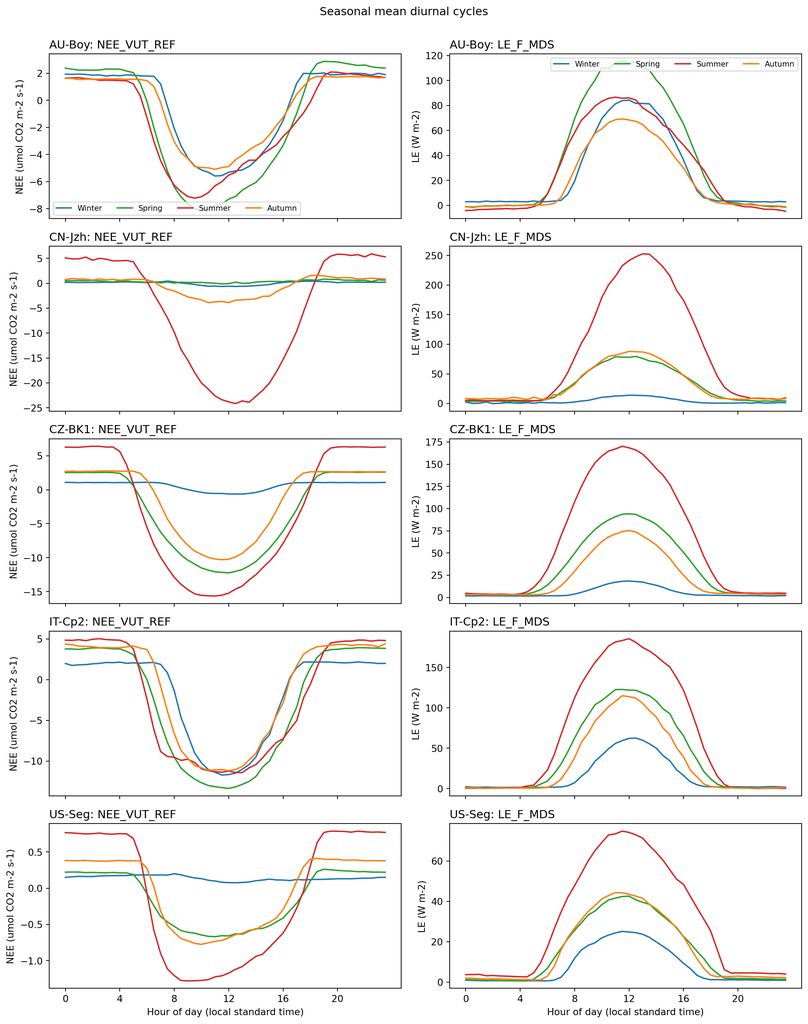

```python
north_season = {
    12: "Winter", 1: "Winter", 2: "Winter",
    3: "Spring", 4: "Spring", 5: "Spring",
    6: "Summer", 7: "Summer", 8: "Summer",
    9: "Autumn", 10: "Autumn", 11: "Autumn",
}
south_season = {
    6: "Winter", 7: "Winter", 8: "Winter",
    9: "Spring", 10: "Spring", 11: "Spring",
    12: "Summer", 1: "Summer", 2: "Summer",
    3: "Autumn", 4: "Autumn", 5: "Autumn",
}
season_colors = {
    "Winter": "tab:blue",
    "Spring": "tab:green",
    "Summer": "tab:red",
    "Autumn": "tab:orange",
}
latitude_by_site = meta.set_index("SITE_ID")["LAT"]
diurnal_parts = []

for site, group in hh_all.groupby("site", sort=True):
    part = group[["time", "NEE_VUT_REF", "LE_F_MDS"]].copy()
    season_lookup = north_season if latitude_by_site[site] >= 0 else south_season
    part["season"] = part["time"].dt.month.map(season_lookup)
    part["hour"] = part["time"].dt.hour + part["time"].dt.minute / 60
    part["site"] = site
    diurnal_parts.append(part)

diurnal = pd.concat(diurnal_parts, ignore_index=True)
diurnal_means = (
    diurnal.groupby(["site", "season", "hour"])[["NEE_VUT_REF", "LE_F_MDS"]]
    .mean()
    .reset_index()
)

fig, axes = plt.subplots(len(sites), 2, figsize=(12, 3 * len(sites)), sharex=True)
for row, site in enumerate(sites):
    site_means = diurnal_means.loc[diurnal_means["site"] == site]
    for column, (variable, ylabel) in enumerate(
        [
            ("NEE_VUT_REF", "NEE (umol CO2 m-2 s-1)"),
            ("LE_F_MDS", "LE (W m-2)"),
        ]
    ):
        ax = axes[row, column]
        for season in ["Winter", "Spring", "Summer", "Autumn"]:
            curve = site_means.loc[site_means["season"] == season]
            if not curve.empty:
                ax.plot(
                    curve["hour"],
                    curve[variable],
                    color=season_colors[season],
                    label=season,
                )
        ax.set_ylabel(ylabel)
        ax.set_title(f"{site}: {variable}", loc="left")
        ax.set_xticks(np.arange(0, 24, 4))
        if row == 0:
            ax.legend(ncol=4, fontsize=8)

axes[-1, 0].set_xlabel("Hour of day (local standard time)")
axes[-1, 1].set_xlabel("Hour of day (local standard time)")
fig.suptitle("Seasonal mean diurnal cycles", y=1.002)
fig.tight_layout()
plt.show()
```

# C6. Your reading

## Energy balance

The tower with the most valid observations is selected. Only half-hours with measured sensible and latent heat (`H_F_MDS_QC == 0` and `LE_F_MDS_QC == 0`) and non-missing values for all four plotted fluxes are used.

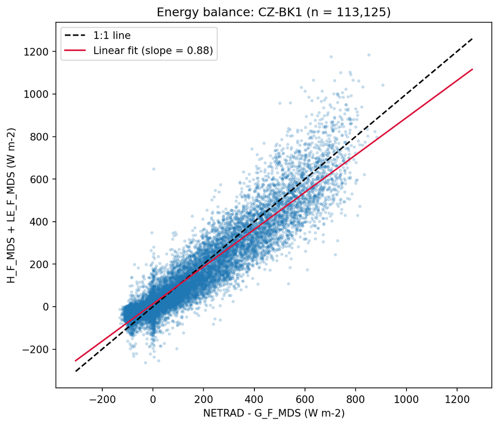

```
Linear-fit slope for CZ-BK1: 0.876.
```

```python
energy_counts = {}
for site, group in hh_all.groupby("site"):
    measured = (
        group["H_F_MDS_QC"].eq(0)
        & group["LE_F_MDS_QC"].eq(0)
        & group[["H_F_MDS", "LE_F_MDS", "NETRAD", "G_F_MDS"]].notna().all(axis=1)
    )
    energy_counts[site] = int(measured.sum())

energy_site = max(energy_counts, key=energy_counts.get)
if energy_counts[energy_site] < 2:
    raise ValueError("No site has enough measured half-hours for an energy-balance fit.")

energy_data = hh_all.loc[hh_all["site"] == energy_site]
measured = (
    energy_data["H_F_MDS_QC"].eq(0)
    & energy_data["LE_F_MDS_QC"].eq(0)
    & energy_data[["H_F_MDS", "LE_F_MDS", "NETRAD", "G_F_MDS"]].notna().all(axis=1)
)
energy_data = energy_data.loc[measured]
x = (energy_data["NETRAD"] - energy_data["G_F_MDS"]).to_numpy()
y = (energy_data["H_F_MDS"] + energy_data["LE_F_MDS"]).to_numpy()
slope, intercept = np.polyfit(x, y, 1)

plot_indices = np.linspace(0, len(x) - 1, min(len(x), 20000), dtype=int)
line_min = min(float(x.min()), float(y.min()))
line_max = max(float(x.max()), float(y.max()))
line = np.linspace(line_min, line_max, 100)

fig, ax = plt.subplots(figsize=(7, 6))
ax.scatter(x[plot_indices], y[plot_indices], s=5, alpha=0.18, rasterized=True)
ax.plot(line, line, color="black", linestyle="--", label="1:1 line")
ax.plot(
    line,
    slope * line + intercept,
    color="crimson",
    label=f"Linear fit (slope = {slope:.2f})",
)
ax.set_xlabel("NETRAD - G_F_MDS (W m-2)")
ax.set_ylabel("H_F_MDS + LE_F_MDS (W m-2)")
ax.set_title(f"Energy balance: {energy_site} (n = {len(x):,})")
ax.legend()
fig.tight_layout()
plt.show()
print(f"Linear-fit slope for {energy_site}: {slope:.3f}.")
```

## Data and citation

The site product citations are taken from the most recent FLUXNET Shuttle snapshot in `data/snapshots` when available. If a snapshot is not present, the report uses `data/raw/CITATIONS.txt`, then the tracked site registry.

```python
from IPython.display import Markdown

snapshot_files = sorted(
    (project_root / "data" / "snapshots").glob("fluxnet_shuttle_snapshot_*.csv"),
    reverse=True,
)
citation_by_site = {}
citation_source = None

if snapshot_files:
    snapshot = pd.read_csv(snapshot_files[0], dtype={"site_id": str})
    required_columns = {"site_id", "product_citation"}
    if not required_columns.issubset(snapshot.columns):
        raise ValueError(
            f"{snapshot_files[0].name} must contain site_id and product_citation columns."
        )
    citation_by_site = (
        snapshot.dropna(subset=["product_citation"])
        .set_index("site_id")["product_citation"]
        .to_dict()
    )
    citation_source = snapshot_files[0].name

if not all(site in citation_by_site for site in sites):
    citation_file = raw_dir / "CITATIONS.txt"
    if citation_file.is_file():
        for line in citation_file.read_text(encoding="utf-8").splitlines():
            if ": " in line:
                site, citation = line.split(": ", maxsplit=1)
                if site in sites and citation.strip():
                    citation_by_site.setdefault(site, citation.strip())

for site in sites:
    citation_by_site.setdefault(site, registry_by_site[site]["cite"])

display(
    Markdown(
        f"Site product citations (snapshot: `{citation_source}`):\n\n"
        + "\n".join(
            f"- **{site}**: {citation_by_site[site]}" for site in sites
        )
    )
)
```

Site product citations (snapshot: `fluxnet_shuttle_snapshot_20261113T111638.csv`):

- **AU-Boy**: Beringer, J., Moore, C. (2026): Boyagin FLUXNET Release 2026_r1. Version 2026_r1. Terrestrial Ecosystem Research Network (TERN). (Dataset).

- **CN-Jzh**: Jia, Q., Zhou, G., Zhou, L. (2026). Fluxnet Archive Product from Jinzhou, 2011–2016, FLUXNET, https://hdl.handle.net/11676/IdPKbpSMd_1dl0ReNyYlmqoX

- **CZ-BK1**: Šigut, L., Bellan, M., Czerný, R., Darenová, E., Fischer, M., Fischer, M., Foltýnová, L., Jocher, G., Joura, L., Klimo, P., Konrádová, P., Kowalska, N., Krejza, J., Marek, M.V., Nezval, O., Pavelka, M., Staník, K., Taufarová, K., Trusina, J., Vitásek, R., Vágner, L., Řehořková, Š., Šlížek, J. (2026). Fluxnet Archive Product from Bily Kriz forest, 2004-01-01–2026-09-06, FLUXNET, https://hdl.handle.net/11676/jFai8tDYa4LFIrBMKJ_Kx3I1

- **IT-Cp2**: Fares, S., Alivernini, A., Chianucci, F., Conte, A., Corsanici, R., Ferrara, C., Fusaro, L., Ilardi, F., Moretti, V., Sorgi, T. (2026). Fluxnet Archive Product from Castelporziano2, 2012-01-01–2026-09-06, FLUXNET, https://hdl.handle.net/11676/Xb6gBcoSkdkQMor4lpYhvGey

- **US-Seg**: Marcy Litvak (2026), AmeriFlux FLUXNET-1F US-Seg Sevilleta grassland, Ver. v1.3_r1 (2007-2025), AmeriFlux AMP, (Dataset). https://doi.org/10.17190/AMF/1984572

Pastorello et al. (2020). The FLUXNET2015 dataset and the ONEFlux processing pipeline for eddy covariance data. *Scientific Data* 7, 225. https://doi.org/10.1038/s41597-020-0534-3

> FLUXNET data products were produced and harmonized by eddy covariance regional networks and data processing centers, including AmeriFlux, ChinaFlux, European Fluxes Database, ICOS, JapanFlux, KoFlux, OzFlux, SAEON, and TERN. These products also include a modified version of ERA5 hourly data provided by the Copernicus Climate Change Service.